# Power Visualization

# Visualizing centrality using ggraph

You have been building up skills and understanding about how `ggraph` works and now we’re ready to start building complex visualizations. Today we’ll work on different ways of showing power.

## Power and networks

Power has long been a central concern of social scientists. The famous sociologist Max Weber defined it as the ability to control others or resources - to realize one’s will.

Some of this power comes in the form of “social capital” - the idea that there is power in our relationships - through mobilizing the resources of those we are connected to.

The construct of network power has many facets and over the years social network analysts have come up with a number of different algorithms for measuring different aspects of power in networks. These are usually called “centrality measures”. The intuition is that those in the center of a visualized network are typically those with the most power.

## Degree centrality

Degree centrality is simply the number of connections that someone has. For directed networks, indegree can be interpreted as popularity and outdegree as gregariousness.

Let’s start with this network. There are a few new things going on here, so I’ll walk through each line:

- `set.seed(23)`: We’re going to be creating a random network. By setting a “seed”, we guarantee we all get the same network.
- `G = as_tbl_graph(random.graph.game(8, .25, directed = T))`: Here’s our random graph - 8 nodes, a .25 probability of each edge, and it’s directed
- `G %>% ggraph() +`

```
## Using `stress` as default layout
```

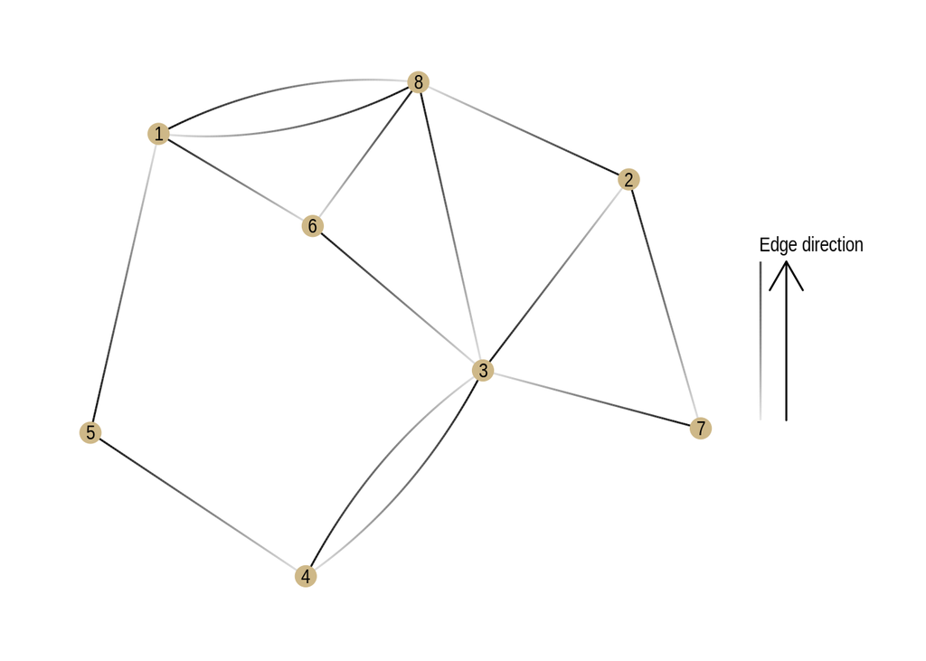

```r
set.seed(23)
G = as_tbl_graph(random.graph.game(8, .25, directed = T))

G %>%
  ggraph() +
  geom_edge_fan(aes(alpha = stat(index))) + # This does gradients for directed edges
  geom_node_point(color = '#ceb888', size = 5) +
  geom_node_text(aes(label = 1:8)) + # Adds labels to nodes
  scale_edge_alpha('Edge direction', guide = 'edge_direction') # Adds the "Edge direction" legend
```

Now, let’s show the degree centrality by changing the size of nodes. Here is the total degree centrality

```
## Using `stress` as default layout
```

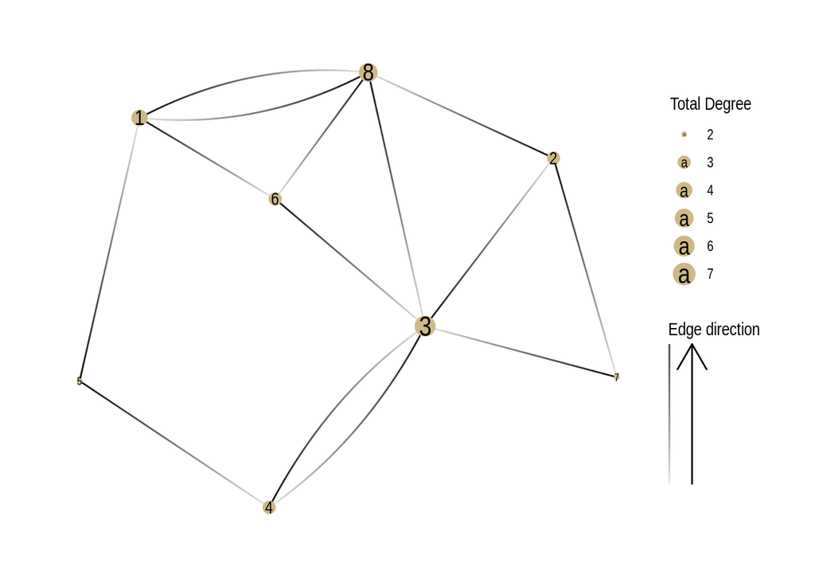

```r
G %>%
  activate(nodes) %>%
  mutate(degree = centrality_degree(mode = 'all')) %>%
  ggraph() +
  geom_edge_fan(aes(alpha = stat(index))) + # This does gradients for directed edges
  geom_node_point(aes(size = degree), color = '#ceb888') +
  geom_node_text(aes(label = 1:8, size=degree *1.2)) +
  scale_edge_alpha('Edge direction', guide = 'edge_direction') + # Adds the "Edge direction" legend
  scale_size(name='Total Degree') # Can you figure out what this is doing?
```

Note how this changes when we show indegree/popularity

```
## Using `stress` as default layout
```

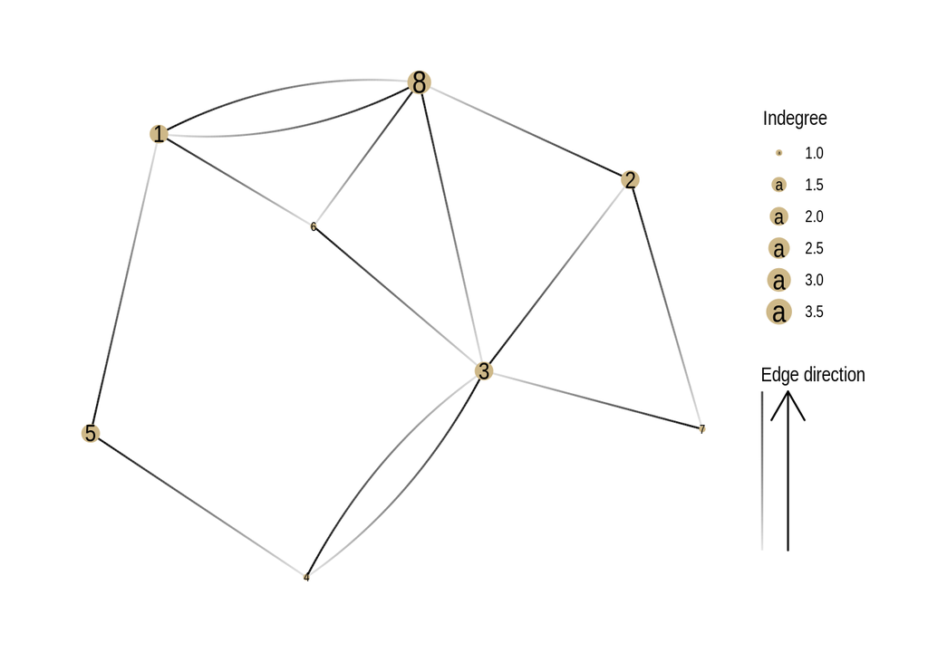

```r
G %>%
  activate(nodes) %>%
  mutate(degree = centrality_degree(mode = 'in')) %>%
  ggraph() +
  geom_edge_fan(aes(alpha = stat(index))) + # This does gradients for directed edges
  geom_node_point(aes(size = degree), color = '#ceb888') +
  geom_node_text(aes(label = 1:8, size=degree * 1.2)) +
  scale_edge_alpha('Edge direction', guide = 'edge_direction') + # Adds the "Edge direction" legend
  scale_size_continuous(name='Indegree')
```

### Exercise

Now it’s your turn. How would you edit the code above to show outdegree (or gregariousness)? What do you learn / notice based on comparing these three measures?

```r
# YOUR CODE HERE
```

YOUR ANSWER HERE

## Closeness Centrality

This measure tries to capture how much a node is literally in the center of a graph. It is a measure of the average distance to each other node.

```
## Using `stress` as default layout
```

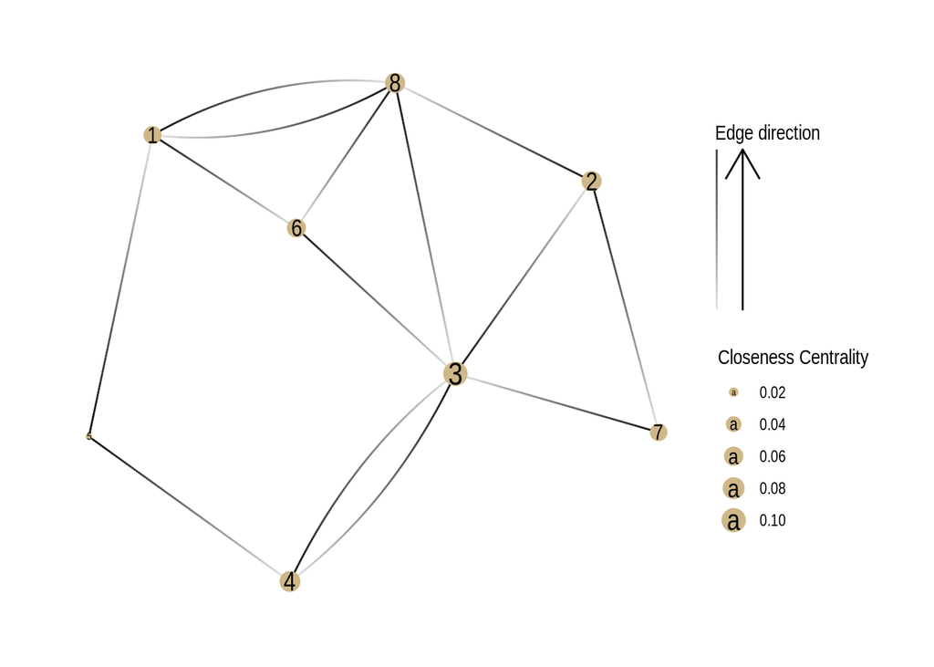

```r
G %>%
  activate(nodes) %>%
  mutate(centrality = centrality_closeness()) %>%
  ggraph() +
  geom_edge_fan(aes(alpha = stat(index))) + # This does gradients for directed edges
  geom_node_point(aes(size = centrality), color = '#ceb888') +
  geom_node_text(aes(label = 1:8, size=centrality * 1.2)) +
  scale_edge_alpha('Edge direction', guide = 'edge_direction') + # Adds the "Edge direction" legend
  scale_size_continuous(name = "Closeness Centrality")
```

### Exercise

What do you notice about what’s different here?

YOUR ANSWER HERE

## Betweenness Centrality

This measure counts the number of shortest paths that go through each node. This is based on the value of being in a “structural hole”.

### Exercise

Look again at the network and guess which nodes will have the highest betweenness centrality.

YOUR ANSWER HERE

After you’ve done that, turn this into a code block (by adding “{r}” after the backticks) and then find the bug in the code below so that it colors the nodes based on betweenness centrality (So far we’ve been using the size of the node to represent centrality, but color is the other common way of showing centrality).

```
G %>%
  activate(nodes) %>%
  mutate(centrality = centrality_betweenness()) %>%
  ggraph() +
  geom_edge_fan(aes(alpha = stat(index))) + # This does gradients for directed edges
  geom_node_point(color = centrality, size = 4) +
  geom_node_text(aes(label = 1:8)) +
  scale_edge_alpha('Edge direction', guide = 'edge_direction') + # Adds the "Edge direction" legend
  scale_color_continuous(name = "Betweenness Centrality")
```

## Eigenvector centrality

The last important measures of centrality is eigenvector centrality. The calculation is complicated and based on matrix algebra but the concept is pretty simple: all else being equal, a node is more powerful if it’s connected to a node that’s well-connected.

This is actually the basis of Google’s original search algorithm, and is part of what made them successful.

### Exercise

```
## Using `stress` as default layout
```

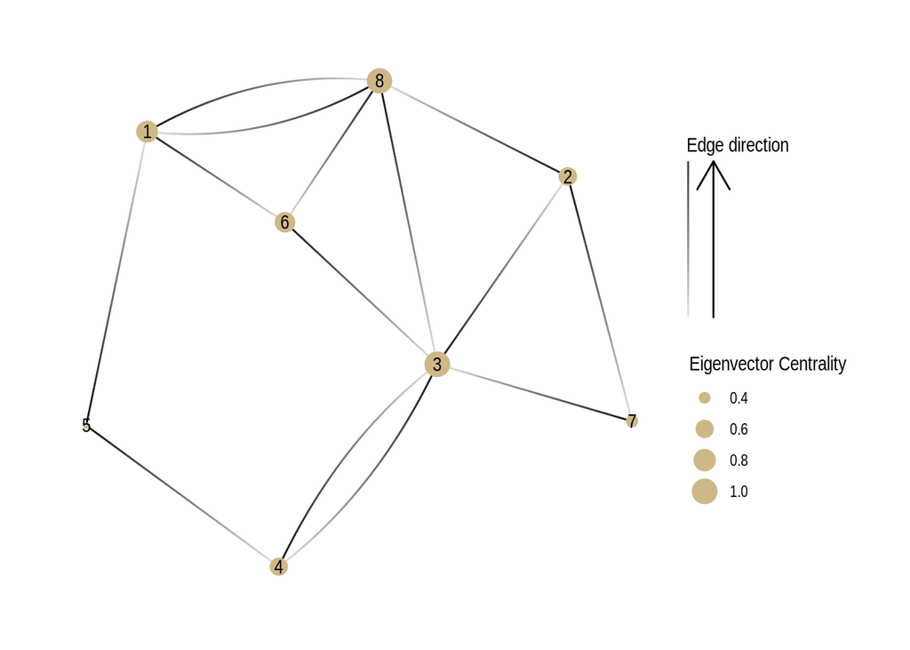

```r
G %>%
  activate(nodes) %>%
  mutate(centrality = centrality_eigen()) %>%
  ggraph() +
  geom_edge_fan(aes(alpha = stat(index))) + # This does gradients for directed edges
  geom_node_point(aes(size = centrality), color = '#ceb888') +
  geom_node_text(aes(label = 1:8)) +
  scale_edge_alpha('Edge direction', guide = 'edge_direction') + # Adds the "Edge direction" legend
  scale_size_continuous(name = "Eigenvector Centrality")
```

### Exercise

Why does Node 5 have such low centrality? Why does 8 have such high centrality?

YOUR ANSWER HERE